# Mount St Helens analog test signal: event flags for catalog v6.1

## 1. The rule (pre-registered)

Written to `RULE.md` at 2026-11-26 16:27:27 PST (time from `date`) and pushed in commit 7ae9b1a9 before any event was scored; md5 of the file now: `61b3513e6de308ba40da3071fcb1d3b7` (registered: 61b3513e6de308ba40da3071fcb1d3b7).

**RULE.md**

```
# Pre-registered rule: Mount St Helens analog test-signal events (catalog v6.1 event_flag)

Registered: 2026-11-26 16:27:27 PST (from `date` on the build machine), before any event was scored.
Decision: D-B108 (PI, 2026-11-26 16:09; workflow/10_tomography/DECISIONS.md on origin/tomo/tiles 7b6b9173).
Code: workflow/10_tomography/msh_flags/ (branch analysis/msh-analog-flags). Flag only: no event is deleted or moved.

## What was looked at before this rule was written (window and channel definition only)

1. Pick timing (maf_hist.py): picks of HSR, EDM, STD.UW per weekday and local hour against all other stations; Wednesday
   11:00-13:30 local in 1-min bins per year; picks per station in the Wednesday noon window against the same clock
   window on the other weekdays. Result: two Wednesday clusters near 11:56-12:00 and 12:16-12:20 local, 2011-2013 only;
   the excess is on about 13 UW analog stations around the volcano, not only HSR, EDM, STD.
2. Continuous data (maf_template.py, maf_scan.py): template of the pulse from 16 traces (2011-11-23 and 2012-05-02, two
   pulses each, HSR/EDM/STD/SHW). Scan of every day 2010-2016 at EDM.UW and every Wednesday at HSR, STD, SHW, ELK.UW,
   11:00-13:30 local. Result: two pulses every Wednesday from 2011-05-18 to 2013-08-28, onsets identical to 0.1 s on all
   channels (common mode), drifting -3.1 s per week; the generator keeps the pre-2007 US DST rule (nine Wednesdays
   with pulses one hour late in local time); on four Wednesdays the plateau lasts from the first to the second pulse;
   13 irregular common-mode pulses on other days or times (2010-2016).
3. Station screen (maf_screen.py): 24 reference pulses at every station with picks within 300 km of the summit.
4. The edge detector (maf_wave.py) was run on 11 hand-chosen times of the continuous data (pulse edges, a long plateau,
   a Tuesday control). No catalog event was classified, and no class counts were computed before this rule.

## Definitions

- **Signal channels S** (maf_screen.py; WORK/signal_stations.json): stations whose vertical channel carries the pulse
  (|cc| >= 0.9 and amplitude/noise >= 5 within 2 s of the reference onset at half or more of the 24 reference pulses
  with data). 25 UW analog stations: HSR SHW EDM STD JUN SOS FL2 CDF ELK TDL MTM LVP LCW BOW NLO VG2 KMO HBO RNO
  (pulse of 700-950 counts) and KOS RVW VLM SSO STW RMW (inverted copy of about 3 counts; RMW from one pulse only).
  No digital station (CC, PB, XD, ...) carries it. HSR, EDM, STD are the three channels named by the v5.1 review.
- **Device time**: UTC - 8 h, plus 1 h from the first Sunday of April 02:00 PST to the last Sunday of October 02:00 PDT
  (pre-2007 US DST rule of the pulse generator). Local time is America/Los_Angeles (PST/PDT, 2007+ rule).
- **Pulse windows W** (maf_calendar.py; WORK/windows.csv), in UTC:
  - weekly pulses, era 2011-05-18 .. 2013-08-28, every Wednesday, pulse 1 (device 11:50-12:05) and pulse 2 (device
    12:10-12:25): detected common-mode onset (two or more scanned stations within 2 s) -40 s .. +90 s; where a pulse was
    not detected, the onset predicted by linear interpolation in device time between the nearest detected Wednesdays,
    -120 s .. +150 s;
  - irregular pulses: common-mode detections outside those windows, onset -40 s .. +90 s.
- **Pick on the signal**: a pick (P or S) on a station of S whose time lies in W.

## Event rule

Scope: every catalog v6.0 event in the Mount St Helens box (46.05-46.30 N, 122.35-122.10 W; v6.0 epicentre, the v4
epicentre for events without a v6.0 hypocentre) and every event with at least one pick on a station of S.
Pick file: Cascadia_picks_catalog_v4.1tc.csv (pick_datetime).

For each event: n_tot = all picks, n_in = picks on the signal, share = n_in / n_tot, n_nonS = picks on stations not in S.

1. **Timing (T)**: n_in >= 3 and share >= 0.5.
2. **Waveform (WF)**: for up to 8 picks on the signal (P first, then by time), read pick - 45 s .. pick + 45 s of the
   station's vertical (pnwstore, record-header time base; raw counts, 10-Hz block means) and correlate the two edge
   templates (onset edge, the negative box masked; plateau end), either polarity. A pick is matched when an edge with
   |cc| >= 0.9 and |amplitude| / noise >= 5 lies at most 3 s after or 10 s before the pick
   (edge - 3 s <= pick <= edge + 10 s). n_wf = picks read with data, n_match = matched picks.
   WF holds when n_match >= 2 and n_match >= 0.5 n_wf.
3. **Real-earthquake guard (G)**: n_nonS <= 3 (an event with four or more picks on stations without the signal may be a
   real earthquake that happened during a pulse; it is not flagged).

Classes:
- **certain** = T and WF and G -> event_flag "analog_test_signal" in event_flags_v61.csv;
- **probable** = T and G, not WF (timing only; WF failed or no waveform) -> listed, not flagged;
- **mixed** = T, not G -> listed for review, not flagged;
- **none** = not T.

The flag file carries "certain" only. Every non-empty v6.0 event_flag is carried over unchanged; an event that already
has a flag and is "certain" gets the two joined with ';' (existing value first).

## Checks reported (no threshold is changed after scoring; any departure is reported as such)

- counts by class, by year, by window kind (weekly / irregular) and by box membership;
- depth of flagged events against unflagged events in the box;
- false-positive checks: (a) events with picks on the signal and 4 or more non-S picks (mixed) are listed and inspected;
  (b) WF run on control events without picks in W (a random sample of 400 events with >= 3 picks on S, and every box
  event on a Wednesday 11:00-13:30 device time outside W): the share of controls with WF true is the false-match rate;
  (c) flagged events with a ComCat match (comcat_id) or a magnitude above 2.5 are listed;
  (d) waveform examples of flagged events and of a real event in or next to a window.
```

## 2. The signal

A calibration-type pulse injected at once on the analog UW channels: a clipped negative box of 1.5 s, an exponential rise to a plateau of 700-950 counts, the plateau end 27.5 s after the onset and an exponential return. Two pulses every Wednesday, about 20 minutes apart. Template (median of 16 traces, plateau normalised; the negative box is masked in the correlation):

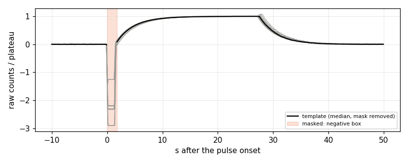

### Raw traces of one Wednesday (2012-05-02): every analog station near the volcano, none of the digital ones

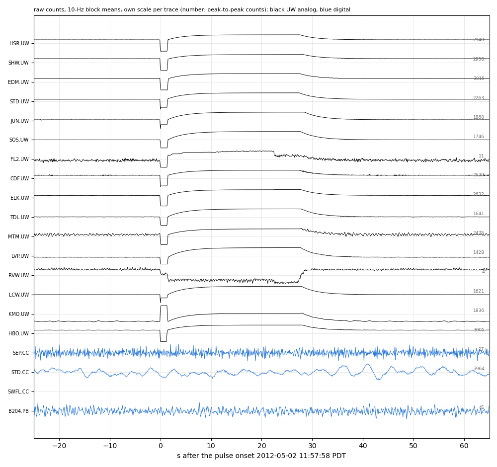

## 3. When: weekday and hour

Picks of HSR, EDM and STD.UW per weekday and local hour (left) and their share against all other stations' picks (right):

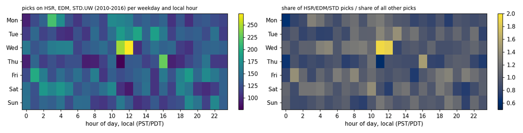

Wednesday 11:00-13:30 local in 1-minute bins, per year (orange: mean of the other weekdays at the same clock time):

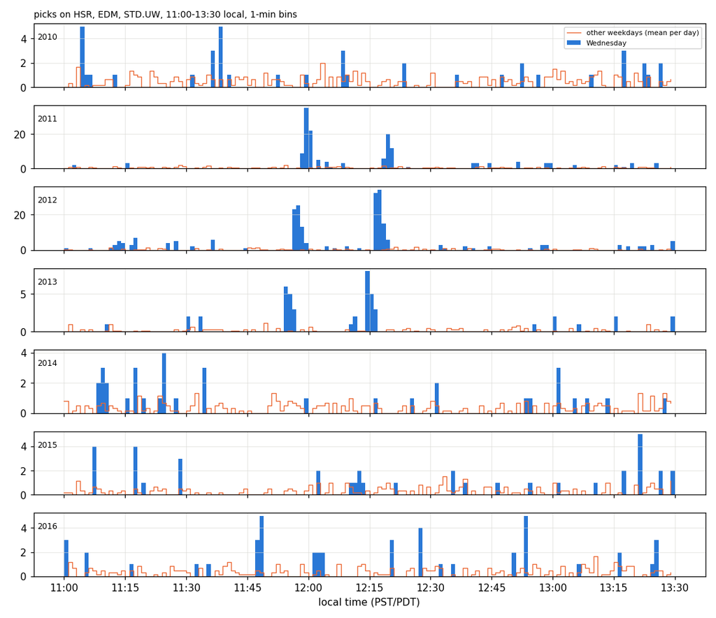

### Pulse calendar from the continuous data

Every day 2010-2016 at EDM.UW and every Wednesday at HSR, STD, SHW and ELK.UW, 11:00-13:30 local, scanned with the template. Weekly pulses from **2011-05-18** to **2013-08-28** (120 Wednesdays; pulse 1 detected on 115, pulse 2 on 111, the others predicted), drifting -3.1 s per week. The generator keeps the **pre-2007 US daylight-saving rule**: in the weeks between the 2007+ change date and the old one the pulses come one hour late in local time (2011-11-02, 2012-03-14, 2012-03-21, 2012-03-28, 2012-10-31, 2013-03-13, 2013-03-20, 2013-03-27, 2013-04-03). In device time the pulses stay at 11:54-12:00 and 12:14-12:20. 13 irregular common-mode pulses (other days or times) are windows too.

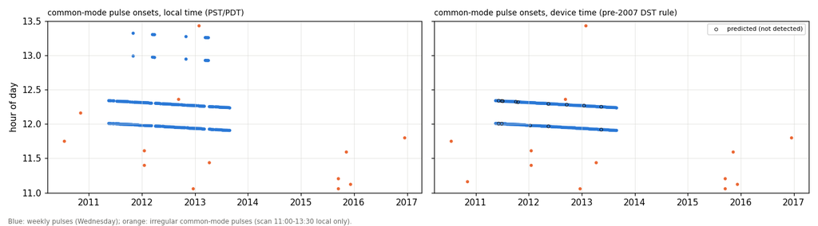

**Irregular common-mode pulses**

| local | device | n_sta | stations |
| --- | --- | --- | --- |
| 2010-07-16 11:44:53 PDT | 2010-07-16 11:44:53 | 2 | EDM.UW,HSR.UW |
| 2010-11-05 12:09:34 PDT | 2010-11-05 11:09:34 | 2 | EDM.UW,HSR.UW |
| 2012-01-18 11:23:50 PST | 2012-01-18 11:23:50 | 2 | EDM.UW,HSR.UW |
| 2012-01-18 11:36:35 PST | 2012-01-18 11:36:35 | 2 | EDM.UW,HSR.UW |
| 2012-09-10 12:21:29 PDT | 2012-09-10 12:21:29 | 2 | EDM.UW,HSR.UW |
| 2012-12-20 11:03:22 PST | 2012-12-20 11:03:22 | 2 | EDM.UW,HSR.UW |
| 2013-01-29 13:25:44 PST | 2013-01-29 13:25:44 | 2 | EDM.UW,HSR.UW |
| 2013-04-10 11:26:10 PDT | 2013-04-10 11:26:10 | 3 | ELK.UW,SHW.UW,STD.UW |
| 2015-09-16 11:03:23 PDT | 2015-09-16 11:03:23 | 2 | EDM.UW,HSR.UW |
| 2015-09-16 11:12:11 PDT | 2015-09-16 11:12:11 | 2 | EDM.UW,HSR.UW |
| 2015-11-10 11:35:29 PST | 2015-11-10 11:35:29 | 2 | EDM.UW,HSR.UW |
| 2015-12-09 11:07:14 PST | 2015-12-09 11:07:14 | 2 | EDM.UW,HSR.UW |
| 2016-12-16 11:47:51 PST | 2016-12-16 11:47:51 | 2 | EDM.UW,HSR.UW |

## 4. Where: channels that carry the signal

|cc| >= 0.9 and amplitude/noise >= 5.0 within +-2.0 s of the reference onset at >= half of the reference pulses with data; 24 reference pulses, every station with picks within 300 km of the summit. 25 UW analog stations; no digital station with data (CC, PB, TA, UO, ...) carries it (the XD and YH deployments came after the pulse era). Six carry an inverted copy of about 3 counts (cc_med < 0).

| station | dist_km | n_data | n_hit | n_hit_neg | cc_med | amp_med |
| --- | --- | --- | --- | --- | --- | --- |
| HSR.UW | 2.10 | 24 | 21 | 0 | 1.00 | 880.72 |
| SHW.UW | 3.20 | 24 | 21 | 1 | 1.00 | 727.01 |
| EDM.UW | 3.40 | 24 | 24 | 0 | 1.00 | 937.65 |
| STD.UW | 5.70 | 24 | 23 | 1 | 1.00 | 884.48 |
| JUN.UW | 5.80 | 24 | 21 | 3 | 1.00 | 835.63 |
| SOS.UW | 7.30 | 24 | 23 | 0 | 1.00 | 886.16 |
| FL2.UW | 12.10 | 24 | 22 | 0 | 1.00 | 925.05 |
| CDF.UW | 14.00 | 24 | 15 | 0 | 0.99 | 784.26 |
| ELK.UW | 17.10 | 24 | 23 | 0 | 1.00 | 928.22 |
| TDL.UW | 17.80 | 24 | 22 | 0 | 1.00 | 797.80 |
| MTM.UW | 18.50 | 24 | 23 | 0 | 1.00 | 838.59 |
| LVP.UW | 21.20 | 24 | 22 | 0 | 1.00 | 821.48 |
| KOS.UW | 30.20 | 24 | 14 | 14 | -0.93 | -3.22 |
| RVW.UW | 42.50 | 24 | 19 | 11 | -0.96 | -2.35 |
| LCW.UW | 66.00 | 24 | 18 | 2 | 1.00 | 814.84 |
| VLM.UW | 73.60 | 24 | 19 | 12 | -0.96 | -2.54 |
| BOW.UW | 85.50 | 24 | 20 | 6 | 0.99 | 854.38 |
| NLO.UW | 97.60 | 23 | 23 | 7 | 0.99 | 862.66 |
| VG2.UW | 115.30 | 23 | 23 | 8 | 1.00 | 849.55 |
| KMO.UW | 117.80 | 24 | 23 | 0 | 1.00 | 889.52 |
| RMW.UW | 144.10 | 1 | 1 | 1 | -0.96 | -3.53 |
| SSO.UW | 149.90 | 24 | 19 | 19 | -0.97 | -3.19 |
| STW.UW | 244.80 | 24 | 20 | 20 | -0.96 | -3.29 |
| HBO.UW | 261.10 | 24 | 20 | 0 | 1.00 | 929.80 |
| RNO.UW | 280.10 | 24 | 15 | 0 | 0.99 | 868.40 |

## 5. Events

| year | certain (flagged) | probable | mixed |
| --- | --- | --- | --- |
| 2010 | 2 | 2 | 0 |
| 2011 | 45 | 1 | 0 |
| 2012 | 61 | 2 | 1 |
| 2013 | 22 | 0 | 2 |
| 2014 | 0 | 0 | 0 |
| 2015 | 0 | 0 | 0 |
| 2016 | 1 | 0 | 0 |

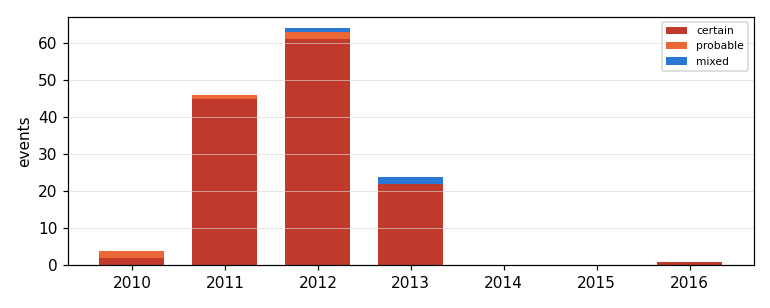

### Depth: flagged events against the other box events

| group | n | median | p16 | p84 | deeper_30km |
| --- | --- | --- | --- | --- | --- |
| certain (flagged) | 94 | 53.65 | 33.25 | 70.48 | 82 |
| probable | 5 | 8.57 | 8.09 | 24.68 | 1 |
| mixed | 0 |  |  |  | 0 |
| unflagged box events | 7463 | 1.51 | -0.30 | 9.01 | 275 |

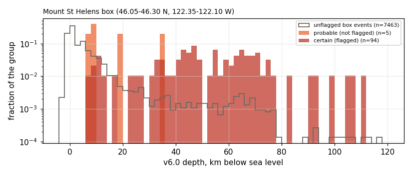

## 6. False-positive checks

Waveform test on control events without picks on the signal (rule check b): an event passes WF only if 2 or more of its picks sit on a pulse edge.

| set | n | wf_true |
| --- | --- | --- |
| control_random | 400 | 0 |
| control_wed_noon_box | 80 | 2 |

Picks tested in the windows: 1022 (1022 with data, 949 matched); certain events by number of picks without the signal: {"0": 127, "1": 4}.

## 7. Examples

### Flagged event 28237

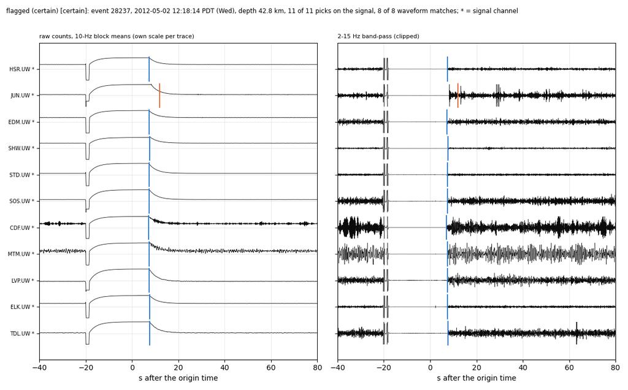

### Flagged event 26754

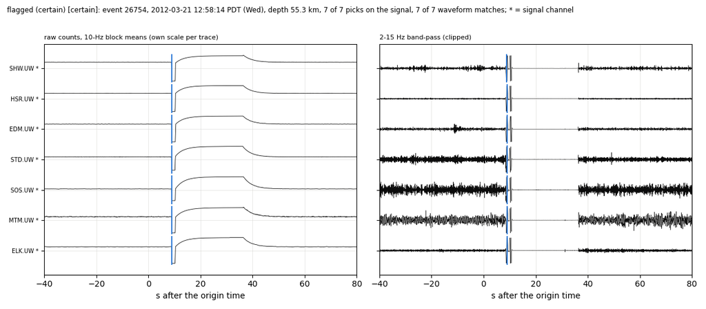

### Flagged event 17439

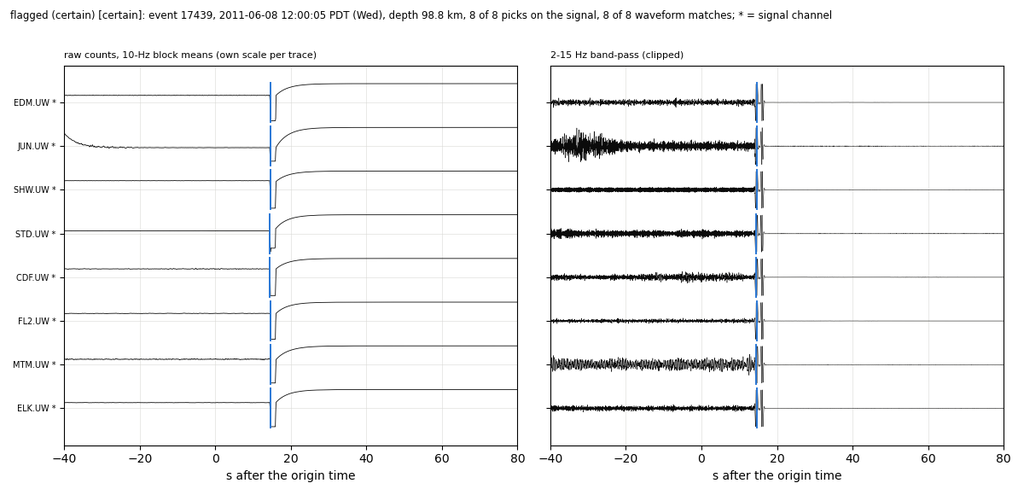

### Flagged event 33276

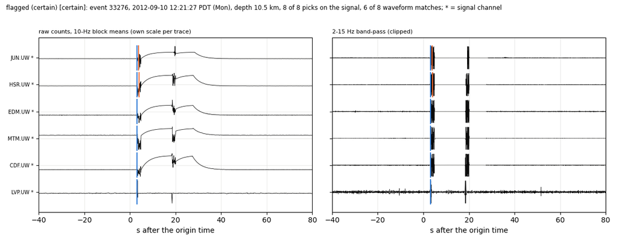

### Real event 27434 in a pulse window (not flagged)

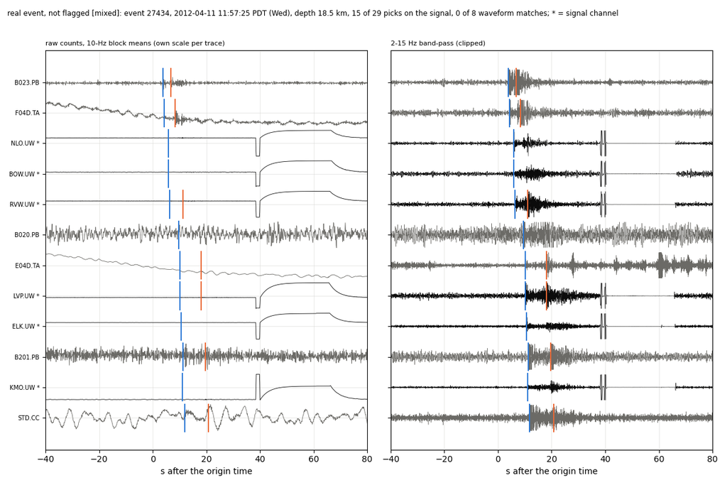

### Real event 63183 in a pulse window (not flagged)

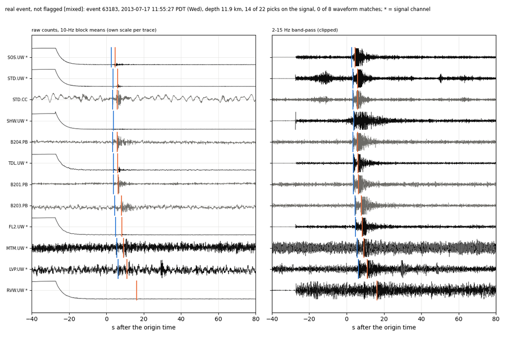

### Probable events (timing only; not flagged by the rule)

Their picks lie in the windows and on signal channels only, but not on a pulse edge: a data gap after a pulse, a short box without a plateau, glitches inside an irregular test sequence. By eye none is an earthquake.

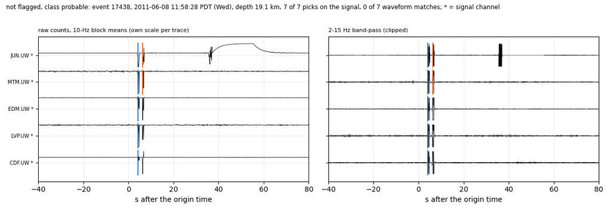

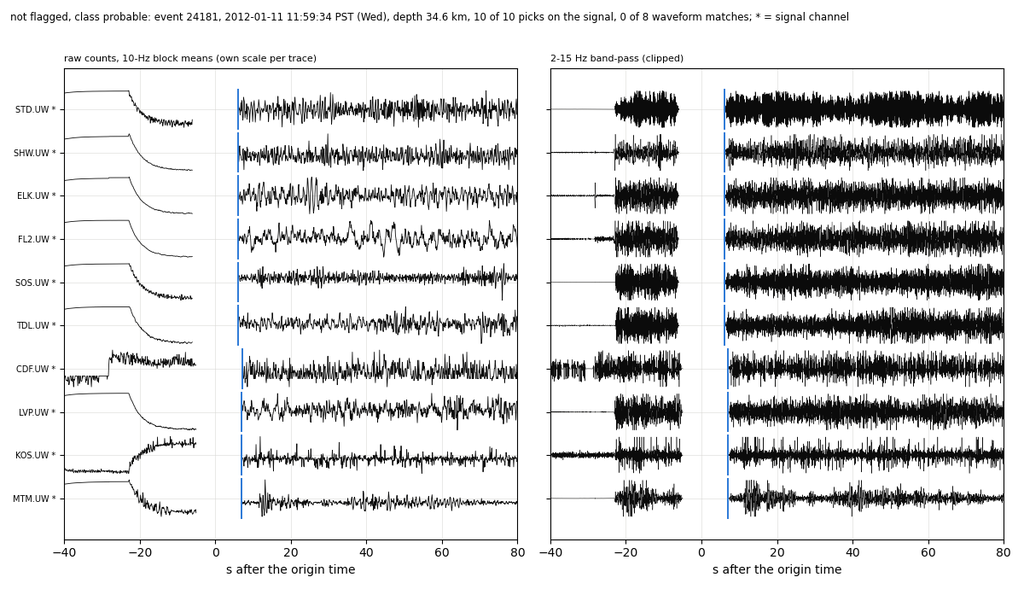

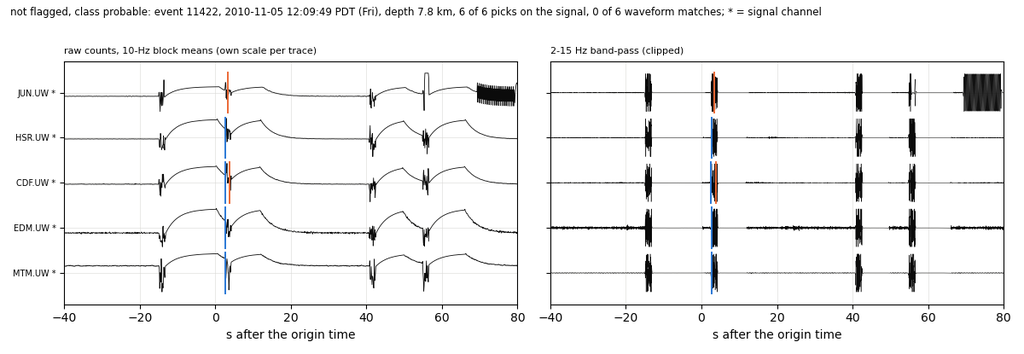

## 7b. Post-hoc sweep: pulse edges outside the windows (not part of the rule; no flag)

| ID | local | lat | lon | depth | tier | M | in_box | n_tot | n_S | n_nonS | S_P_span_s | n_wf | n_match | n_sta_match | comcat_id |
| --- | --- | --- | --- | --- | --- | --- | --- | --- | --- | --- | --- | --- | --- | --- | --- |
| 43 | 2010-01-02 10:19:30 PST Sat | 46.13 | -122.45 | 17.11 | C | 2.43 | False | 7 | 7 | 0 | 0.15 | 4 | 4 | 4 |  |
| 3181 | 2010-03-03 15:44:21 PST Wed | 46.15 | -122.38 | 69.44 | C | 2.64 | False | 7 | 7 | 0 | 0.08 | 4 | 4 | 4 |  |
| 3182 | 2010-03-03 15:45:08 PST Wed | 45.89 | -122.41 | 6.36 | D | 1.26 | False | 6 | 6 | 0 | 0.32 | 4 | 4 | 4 |  |
| 3184 | 2010-03-03 15:55:18 PST Wed | 46.19 | -122.30 | 30.93 | D | 1.46 | True | 6 | 6 | 0 | 0.30 | 4 | 4 | 4 |  |
| 3985 | 2010-03-26 14:06:08 PDT Fri | 46.12 | -122.19 | 8.28 | D | 1.88 | True | 5 | 5 | 0 | 0.07 | 4 | 4 | 4 |  |
| 8194 | 2010-08-04 13:23:16 PDT Wed | 46.20 | -122.14 | 61.70 | D | 1.38 | True | 5 | 5 | 0 | 0.21 | 4 | 4 | 4 |  |
| 11397 | 2010-11-04 16:51:35 PDT Thu | 46.11 | -122.18 | 5.70 | C | 1.66 | True | 7 | 7 | 0 | 0.04 | 4 | 4 | 4 |  |
| 11399 | 2010-11-04 16:53:00 PDT Thu | 46.12 | -122.18 | 13.14 | D | 0.74 | True | 5 | 4 | 1 | 0.19 | 4 | 4 | 4 |  |
| 12550 | 2010-12-14 10:00:18 PST Tue | 46.11 | -122.17 | 3.48 | C | 1.69 | True | 6 | 6 | 0 | 0.22 | 4 | 2 | 2 |  |
| 12556 | 2010-12-14 13:44:08 PST Tue | 46.12 | -122.23 | 10.27 | C | 1.90 | True | 7 | 7 | 0 | 0.03 | 4 | 4 | 4 |  |
| 12561 | 2010-12-14 15:27:01 PST Tue | 46.11 | -122.22 | 14.76 | D | 1.79 | True | 6 | 6 | 0 | 0.11 | 4 | 3 | 3 |  |
| 12579 | 2010-12-15 05:34:52 PST Wed | 46.12 | -122.21 | 11.15 | C | 1.85 | True | 7 | 7 | 0 | 0.06 | 4 | 2 | 2 |  |
| 12661 | 2010-12-18 06:46:23 PST Sat | 46.16 | -122.27 | 12.62 | B | 2.23 | True | 9 | 9 | 0 | 0.26 | 4 | 4 | 4 |  |
| 13597 | 2011-01-25 00:37:16 PST Tue | 46.12 | -122.25 | 10.93 | D | 1.90 | True | 5 | 5 | 0 | 0.08 | 7 | 5 | 3 |  |
| 13709 | 2011-01-27 16:45:02 PST Thu | 46.13 | -122.21 | 9.01 | C | 1.88 | True | 6 | 6 | 0 | 0.15 | 4 | 4 | 4 |  |
| 13711 | 2011-01-27 16:47:40 PST Thu | 46.12 | -122.19 | 8.94 | C | 1.90 | True | 6 | 6 | 0 | 0.15 | 4 | 3 | 3 |  |
| 13712 | 2011-01-27 16:48:34 PST Thu | 46.12 | -122.19 | 10.49 | C | 1.91 | True | 6 | 6 | 0 | 0.08 | 4 | 4 | 4 |  |
| 13713 | 2011-01-27 16:49:47 PST Thu | 46.12 | -122.33 | 0.46 | D | 2.18 | True | 5 | 5 | 0 | 0.10 | 4 | 3 | 3 |  |
| 13716 | 2011-01-27 16:53:35 PST Thu | 46.10 | -122.16 | 5.59 | B | 1.71 | True | 8 | 8 | 0 | 0.07 | 4 | 4 | 4 |  |
| 13737 | 2011-01-28 08:11:21 PST Fri | 46.11 | -122.23 | 11.00 | C | 1.86 | True | 8 | 8 | 0 | 0.11 | 4 | 4 | 4 |  |
| 14771 | 2011-02-28 16:08:38 PST Mon | 46.19 | -122.23 | 74.54 | C | 2.73 | True | 6 | 6 | 0 | 0.13 | 4 | 4 | 4 |  |
| 15930 | 2011-04-15 09:28:19 PDT Fri | 46.12 | -122.14 | 3.04 | D | 1.54 | True | 7 | 7 | 0 | 0.68 | 4 | 2 | 2 |  |
| 15939 | 2011-04-15 16:37:20 PDT Fri | 46.18 | -122.20 | 69.87 | D | 2.72 | True | 5 | 5 | 0 | 0.05 | 4 | 4 | 4 |  |
| 15944 | 2011-04-15 16:47:31 PDT Fri | 46.11 | -122.16 | 4.00 | C | 1.71 | True | 6 | 6 | 0 | 0.09 | 5 | 5 | 4 |  |
| 15946 | 2011-04-15 16:49:06 PDT Fri | 46.20 | -122.32 | 63.45 | D | 3.21 | True | 6 | 6 | 0 | 0.11 | 5 | 5 | 4 |  |
| 16083 | 2011-04-20 16:10:20 PDT Wed | 46.18 | -122.22 | 69.29 | D | 1.78 | True | 5 | 5 | 0 | 0.04 | 4 | 4 | 4 |  |
| 16507 | 2011-05-04 14:27:37 PDT Wed | 46.12 | -122.19 | 7.17 | D | 1.93 | True | 5 | 4 | 1 | 0.06 | 4 | 4 | 4 |  |
| 16511 | 2011-05-04 16:01:04 PDT Wed | 46.13 | -122.23 | 8.05 | C | 1.91 | True | 6 | 5 | 1 | 0.19 | 5 | 5 | 4 |  |
| 16512 | 2011-05-04 16:05:23 PDT Wed | 46.14 | -122.24 | 4.96 | C | 2.04 | True | 6 | 5 | 1 | 0.12 | 4 | 4 | 4 |  |
| 16517 | 2011-05-04 18:11:23 PDT Wed | 46.15 | -122.24 | 9.31 | D | 2.03 | True | 5 | 4 | 1 | 0.06 | 5 | 4 | 3 |  |
| 23135 | 2011-12-13 05:27:44 PST Tue | 46.18 | -122.26 | 52.92 | C | 1.97 | True | 10 | 10 | 0 | 0.29 | 4 | 2 | 2 |  |
| 23380 | 2011-12-19 00:28:12 PST Mon | 46.46 | -122.01 | 63.30 | C | 1.91 | False | 7 | 5 | 2 | 0.15 | 4 | 2 | 2 |  |
| 31717 | 2012-08-03 10:42:09 PDT Fri | 46.11 | -122.16 | 6.21 | D | 1.64 | True | 5 | 5 | 0 | 0.08 | 4 | 4 | 4 |  |
| 41541 | 2012-11-17 06:48:17 PST Sat | 46.17 | -122.10 | 3.48 | C | 1.62 | True | 6 | 6 | 0 | 0.15 | 4 | 4 | 4 |  |
| 41543 | 2012-11-17 07:24:20 PST Sat | 46.13 | -122.22 | 51.16 | C | 2.58 | True | 6 | 6 | 0 | 0.21 | 4 | 4 | 4 |  |
| 41559 | 2012-11-17 10:49:07 PST Sat | 46.13 | -122.20 | 12.99 | D | 1.86 | True | 6 | 6 | 0 | 0.24 | 4 | 4 | 4 |  |
| 43888 | 2012-12-17 03:20:25 PST Mon | 46.11 | -122.23 | 2.01 | D | 1.81 | True | 5 | 5 | 0 | 0.05 | 4 | 4 | 4 |  |
| 43897 | 2012-12-17 07:55:04 PST Mon | 46.09 | -122.22 | 9.01 | D | 1.96 | True | 5 | 5 | 0 | 0.08 | 4 | 3 | 3 |  |
| 44727 | 2012-12-27 10:14:48 PST Thu | 46.12 | -122.16 | 7.47 | D | 1.59 | True | 5 | 5 | 0 | 0.47 | 6 | 3 | 2 |  |
| 44736 | 2012-12-27 12:19:18 PST Thu | 46.08 | -122.20 | 13.80 | C | 1.93 | True | 6 | 6 | 0 | 0.58 | 5 | 3 | 3 |  |
| 44744 | 2012-12-27 14:21:53 PST Thu | 46.12 | -122.23 | 19.03 | C | 2.13 | True | 6 | 6 | 0 | 0.42 | 4 | 3 | 3 |  |
| 44886 | 2012-12-29 08:54:39 PST Sat | 46.11 | -122.23 | 21.38 | C | 2.23 | True | 6 | 6 | 0 | 0.50 | 4 | 2 | 2 |  |
| 45543 | 2013-01-06 23:59:09 PST Sun | 46.14 | -122.12 | 21.53 | D | 1.68 | True | 5 | 5 | 0 | 0.37 | 3 | 2 | 2 |  |
| 56862 | 2013-05-11 00:53:11 PDT Sat | 46.27 | -122.28 | 5.33 | D | 1.76 | True | 7 | 7 | 0 | 0.15 | 4 | 3 | 3 |  |
| 60802 | 2013-06-20 09:13:27 PDT Thu | 46.47 | -122.46 | 76.57 | D | 1.74 | False | 6 | 6 | 0 | 0.74 | 4 | 4 | 4 |  |
| 70859 | 2013-09-29 19:46:45 PDT Sun | 46.10 | -122.22 | 53.95 | C | 1.84 | True | 6 | 6 | 0 | 0.62 | 4 | 4 | 4 |  |
| 70860 | 2013-09-29 20:04:18 PDT Sun | 46.08 | -122.22 | 42.74 | C | 1.57 | True | 7 | 6 | 1 | 0.59 | 4 | 4 | 4 |  |
| 70861 | 2013-09-29 20:14:35 PDT Sun | 46.03 | -122.19 | 55.99 | C | 1.71 | False | 7 | 7 | 0 | 0.64 | 4 | 4 | 4 |  |
| 70863 | 2013-09-29 20:22:50 PDT Sun | 46.12 | -122.24 | 50.43 | C | 1.64 | True | 6 | 6 | 0 | 0.64 | 4 | 4 | 4 |  |
| 70865 | 2013-09-29 20:33:44 PDT Sun | 46.05 | -122.23 | 18.95 | C | 1.18 | False | 6 | 6 | 0 | 0.60 | 4 | 4 | 4 |  |
| 70866 | 2013-09-29 20:55:45 PDT Sun | 46.09 | -122.23 | 19.03 | D | 1.18 | True | 6 | 6 | 0 | 0.55 | 4 | 4 | 4 |  |
| 70877 | 2013-09-30 03:46:18 PDT Mon | 46.21 | -122.25 | 10.41 | D | 1.42 | True | 5 | 5 | 0 | 0.35 | 4 | 4 | 4 |  |
| 70879 | 2013-09-30 05:21:03 PDT Mon | 46.04 | -122.06 | 4.89 | C | 0.98 | False | 8 | 5 | 3 | 0.32 | 4 | 4 | 4 |  |
| 70893 | 2013-09-30 14:24:57 PDT Mon | 46.12 | -122.24 | 13.43 | D | 2.05 | True | 5 | 5 | 0 | 0.09 | 4 | 2 | 2 |  |
| 70894 | 2013-09-30 14:26:04 PDT Mon | 46.09 | -122.22 | 26.52 | C | 1.19 | True | 6 | 6 | 0 | 0.52 | 4 | 4 | 4 |  |
| 96039 | 2014-07-12 12:10:19 PDT Sat | 46.27 | -122.25 | 21.97 | C | 0.87 | True | 6 | 6 | 0 | 0.28 | 4 | 4 | 4 |  |
| 100329 | 2014-08-26 16:50:27 PDT Tue | 46.11 | -122.23 | 13.51 | C | 1.93 | True | 6 | 6 | 0 | 0.02 | 4 | 3 | 3 |  |
| 100330 | 2014-08-26 16:54:18 PDT Tue | 46.12 | -122.18 | 6.73 | D | 1.45 | True | 5 | 5 | 0 | 0.17 | 4 | 3 | 3 |  |
| 103318 | 2014-09-29 15:11:35 PDT Mon | 46.18 | -122.21 | 61.70 | C | 2.85 | True | 9 | 9 | 0 | 0.18 | 4 | 4 | 4 |  |
| 104183 | 2014-10-08 14:19:49 PDT Wed | 46.22 | -122.32 | 32.25 | C | 1.31 | True | 6 | 6 | 0 | 0.32 | 4 | 4 | 4 |  |
| 110993 | 2014-12-13 23:48:05 PST Sat | 46.13 | -122.02 | 23.58 | D | 0.88 | False | 5 | 5 | 0 | 0.70 | 4 | 4 | 4 |  |
| 138651 | 2015-04-06 09:40:21 PDT Mon | 46.23 | -122.28 | 9.71 | B | 1.97 | True | 9 | 9 | 0 | 0.20 | 4 | 4 | 4 |  |
| 138710 | 2015-04-06 13:30:51 PDT Mon | 46.27 | -122.29 | 6.88 | C | 1.79 | True | 7 | 7 | 0 | 0.11 | 4 | 4 | 4 |  |
| 154079 | 2015-07-06 08:16:17 PDT Mon | 46.27 | -122.26 | 23.66 | C | 0.96 | True | 8 | 8 | 0 | 0.43 | 4 | 4 | 4 |  |
| 162461 | 2015-10-23 10:37:19 PDT Fri | 46.13 | -122.24 | 9.23 | C | 1.71 | True | 6 | 6 | 0 | 0.08 | 4 | 4 | 4 |  |
| 170930 | 2016-09-13 07:33:32 PDT Tue | 46.11 | -122.16 | 1.94 | C | 1.81 | True | 6 | 5 | 1 | 0.08 | 4 | 4 | 4 |  |
| 172120 | 2016-12-08 15:36:09 PST Thu | 46.16 | -122.11 | 0.09 | D | 1.47 | True | 5 | 5 | 0 | 0.05 | 3 | 3 | 3 |  |
| 172205 | 2016-12-18 12:07:36 PST Sun | 46.19 | -122.10 | 2.97 | C | 1.68 | False | 6 | 6 | 0 | 0.51 | 4 | 3 | 3 |  |

## 8. Candidate list

certain, probable and mixed events (v6.0 hypocentres; local time PST/PDT).

| ID | cls | local | lat | lon | depth | tier | M | n_tot | n_in | n_nonS | share | n_wf | n_match | in_box | comcat_id | window |
| --- | --- | --- | --- | --- | --- | --- | --- | --- | --- | --- | --- | --- | --- | --- | --- | --- |
| 7467 | certain | 2010-07-16 11:44:49 PDT Fri | 46.24 | -122.27 | 9.53 | C | 2.18 | 6 | 5 | 1 | 0.83 | 5 | 4 | True |  | irregular:detected |
| 11421 | certain | 2010-11-05 12:09:31 PDT Fri | 46.12 | -122.17 | 12.92 | C | 1.93 | 7 | 7 | 0 | 1.00 | 7 | 4 | True |  | irregular:detected |
| 17269 | certain | 2011-06-01 12:20:39 PDT Wed | 46.14 | -122.23 | 27.85 | C | 0.99 | 9 | 9 | 0 | 1.00 | 8 | 8 | True |  | weekly:detected |
| 17439 | certain | 2011-06-08 12:00:05 PDT Wed | 46.18 | -122.15 | 98.79 | D | 3.22 | 8 | 8 | 0 | 1.00 | 8 | 8 | True |  | weekly:predicted |
| 17584 | certain | 2011-06-15 12:20:33 PDT Wed | 46.12 | -122.23 | 46.63 | C | 1.45 | 10 | 10 | 0 | 1.00 | 8 | 8 | True |  | weekly:detected |
| 17726 | certain | 2011-06-22 12:00:35 PDT Wed | 46.15 | -122.27 | 48.24 | C | 1.39 | 6 | 6 | 0 | 1.00 | 6 | 6 | True |  | weekly:detected |
| 17727 | certain | 2011-06-22 12:20:31 PDT Wed | 46.13 | -122.23 | 42.82 | C | 1.16 | 9 | 9 | 0 | 1.00 | 8 | 8 | True |  | weekly:detected |
| 18068 | certain | 2011-07-06 12:00:31 PDT Wed | 46.16 | -122.32 | 64.76 | C | 1.07 | 9 | 9 | 0 | 1.00 | 8 | 8 | True |  | weekly:detected |
| 18459 | certain | 2011-07-20 11:59:58 PDT Wed | 46.22 | -122.16 | 70.46 | C | 2.82 | 8 | 8 | 0 | 1.00 | 8 | 8 | True |  | weekly:detected |
| 18851 | certain | 2011-08-03 12:20:05 PDT Wed | 46.13 | -122.23 | 44.57 | C | 1.31 | 11 | 11 | 0 | 1.00 | 8 | 8 | True |  | weekly:detected |
| 19084 | certain | 2011-08-10 12:00:04 PDT Wed | 46.15 | -122.30 | 68.12 | C | 1.70 | 10 | 10 | 0 | 1.00 | 8 | 8 | True |  | weekly:detected |
| 19087 | certain | 2011-08-10 12:19:37 PDT Wed | 46.06 | -122.50 | 1.94 | D | 2.38 | 7 | 6 | 1 | 0.86 | 6 | 6 | False |  | weekly:detected |
| 19297 | certain | 2011-08-17 11:59:31 PDT Wed | 46.20 | -122.16 | 106.78 | C | 3.15 | 10 | 10 | 0 | 1.00 | 8 | 8 | True |  | weekly:detected |
| 19480 | certain | 2011-08-24 11:59:39 PDT Wed | 46.18 | -122.20 | 17.77 | C | 2.14 | 7 | 7 | 0 | 1.00 | 7 | 7 | True |  | weekly:detected |
| 19481 | certain | 2011-08-24 12:00:04 PDT Wed | 45.95 | -122.16 | 21.67 | D | 0.95 | 5 | 5 | 0 | 1.00 | 5 | 5 | False |  | weekly:detected |
| 19482 | certain | 2011-08-24 12:19:59 PDT Wed | 46.19 | -122.23 | 47.06 | C | 1.51 | 9 | 9 | 0 | 1.00 | 8 | 8 | True |  | weekly:detected |
| 19679 | certain | 2011-08-31 11:59:59 PDT Wed | 46.13 | -122.30 | 66.52 | C | 1.27 | 10 | 10 | 0 | 1.00 | 8 | 8 | True |  | weekly:detected |
| 20301 | certain | 2011-09-14 11:59:28 PDT Wed | 46.19 | -122.21 | 68.71 | C | 3.11 | 8 | 8 | 0 | 1.00 | 8 | 8 | True |  | weekly:detected |
| 20302 | certain | 2011-09-14 11:59:56 PDT Wed | 46.17 | -122.30 | 64.62 | C | 1.31 | 8 | 8 | 0 | 1.00 | 8 | 8 | True |  | weekly:detected |
| 20304 | certain | 2011-09-14 12:19:23 PDT Wed | 46.19 | -122.20 | 70.46 | C | 3.21 | 7 | 7 | 0 | 1.00 | 7 | 7 | True |  | weekly:detected |
| 20517 | certain | 2011-09-21 11:59:34 PDT Wed | 46.11 | -122.26 | 6.51 | C | 1.94 | 7 | 7 | 0 | 1.00 | 7 | 7 | True |  | weekly:detected |
| 20518 | certain | 2011-09-21 11:59:54 PDT Wed | 46.17 | -122.27 | 64.62 | C | 1.56 | 10 | 10 | 0 | 1.00 | 8 | 8 | True |  | weekly:detected |
| 20849 | certain | 2011-10-05 11:59:22 PDT Wed | 46.18 | -122.23 | 65.20 | C | 3.06 | 9 | 9 | 0 | 1.00 | 8 | 8 | True |  | weekly:detected |
| 21042 | certain | 2011-10-12 12:19:00 PDT Wed | 46.17 | -122.24 | 62.86 | C | 2.54 | 8 | 8 | 0 | 1.00 | 8 | 8 | True |  | weekly:detected |
| 21253 | certain | 2011-10-19 11:59:16 PDT Wed | 46.19 | -122.24 | 74.40 | C | 3.15 | 10 | 10 | 0 | 1.00 | 8 | 8 | True |  | weekly:detected |
| 21254 | certain | 2011-10-19 11:59:47 PDT Wed | 46.15 | -122.37 | 50.58 | D | 1.23 | 6 | 6 | 0 | 1.00 | 6 | 6 | False |  | weekly:detected |
| 21465 | certain | 2011-10-26 11:59:14 PDT Wed | 46.18 | -122.22 | 63.45 | C | 2.94 | 8 | 8 | 0 | 1.00 | 8 | 8 | True |  | weekly:detected |
| 21466 | certain | 2011-10-26 11:59:42 PDT Wed | 46.17 | -122.30 | 63.74 | D | 1.39 | 7 | 7 | 0 | 1.00 | 7 | 7 | True |  | weekly:detected |
| 21467 | certain | 2011-10-26 12:18:58 PDT Wed | 46.16 | -122.25 | 32.11 | C | 2.77 | 10 | 10 | 0 | 1.00 | 8 | 8 | True |  | weekly:detected |
| 21662 | certain | 2011-11-02 12:59:39 PDT Wed | 46.15 | -122.23 | 47.50 | C | 1.72 | 10 | 10 | 0 | 1.00 | 8 | 8 | True |  | weekly:detected |

[output cut: 109 more lines]